# Predicting the Strength of high performance concrete

## Description:

### Data Description: The actual concrete compressive strength (MPa) for a given mixture under a specific age (days) was determined from laboratory. Data is in raw form (not scaled).The data has 8 quantitative input variables, and 1 quantitative output variable, and 1030 instances (observations).

### Domain: Material manufacturing

### Context: Concrete is the most important material in civil engineering. The concrete compressive strength is a highly nonlinear function of age and ingredients. These ingredients include cement, blast furnace slag, fly ash, water, superplasticizer, coarse aggregate, and fine aggregate.

### Attribute Information:

- Cement : measured in kg in a m3 mixture
- Blast : measured in kg in a m3 mixture
- Fly ash : measured in kg in a m3 mixture
- Water : measured in kg in a m3 mixture
- Superplasticizer : measured in kg in a m3 mixture
- Coarse Aggregate : measured in kg in a m3 mixture
- Fine Aggregate : measured in kg in a m3 mixture
- Age : day (1~365)
- Concrete compressive strength measured in MPa

### Learning Outcomes:

- Exploratory Data Analysis
- Building ML models for regression
- Hyper parameter tuning

### Objective: Modeling of strength of high performance concrete using Machine Learning

#### Steps and tasks:

##### 1. Deliverable -1 (Exploratory data quality report reflecting the following)

```
a. Univariate analysis
    i. Univariate analysis – data types and description of the independent attributes which should include (name, meaning, range of values observed, central values (mean and median), standard deviation and quartiles, analysis of the body of distributions / tails,  missing values, outliers
b. Multivariate analysis
    i. Bi-variate analysis between the predictor variables and between the predictor variables and target column. Comment on your findings in terms of their relationship and degree of relation if any. Presence of leverage points. Visualize the analysis using boxplots and pair plots, histograms or density curves. Select the most appropriate attributes
c. Strategies to address the different data challenges such as data pollution, outliers and missing values
```

##### 2. Deliverable -2 (Feature Engineering techniques)

```
a. Identify opportunities (if any) to create a composite feature, drop a feature
b. Decide on complexity of the model, should it be simple linear mode in terms of parameters or would a quadratic or higher degree help
c. Explore for gaussians. If data is likely to be a mix of gaussians, explore individual clusters and present your findings in terms of the independent attributes and their suitability to predict strength
```

##### 3. Deliverable -3 (create the model )

```
a. Obtain feature importance for the individual features using multiple methods and present your findings
```

##### 4. Deliverable -4 (Tuning the model)

```
a. Algorithms that you think will be suitable for this project
b. Techniques employed to squeeze that extra performance out of the model without making it overfit or underfit
c. Model performance range at 95% confidence level
```

# Importing packages and Reading file as DataFrame

```python
import pandas as pd #For Pandas
import numpy as np #For Numpy
import seaborn as sns #For Seaborn
import matplotlib.pyplot as plt #For matplotlib

from scipy.stats import zscore #For ZScore
from sklearn.model_selection import train_test_split #For train test split
from sklearn.linear_model import LinearRegression,Ridge,Lasso #for LinearRegressor
from sklearn.tree import DecisionTreeRegressor #for DecisionTree Regressor
from sklearn.ensemble import RandomForestRegressor,GradientBoostingRegressor,AdaBoostRegressor,BaggingRegressor#For Ensemble Techniques
from sklearn.neighbors import KNeighborsRegressor #for KNearest Regressor
from sklearn.svm import SVR #for Support Vector Regressor
import statsmodels.formula.api as sm #For Linear Regression



from sklearn.metrics import mean_squared_error,mean_absolute_error,r2_score #For Scoring
from math import sqrt #For Square Root
from sklearn.preprocessing import PolynomialFeatures #For Ploynomial Features
from sklearn.decomposition import PCA #for PCA
from sklearn.model_selection import GridSearchCV,RandomizedSearchCV #For Cross Validation
from sklearn.pipeline import Pipeline,make_pipeline #For pipeline
from sklearn.model_selection import KFold,cross_val_score #For KFold Crossvalidation
from sklearn.preprocessing import StandardScaler #For StandardScaler
```

```python
DataFrame=pd.read_csv('concrete.csv') #Import Data from CSV
DataFrame.head()#Head of the DataFrame
```

|  | cement | slag | ash | water | superplastic | coarseagg | fineagg | age | strength |
| --- | --- | --- | --- | --- | --- | --- | --- | --- | --- |
| 0 | 141.3 | 212.0 | 0.0 | 203.5 | 0.0 | 971.8 | 748.5 | 28 | 29.89 |
| 1 | 168.9 | 42.2 | 124.3 | 158.3 | 10.8 | 1080.8 | 796.2 | 14 | 23.51 |
| 2 | 250.0 | 0.0 | 95.7 | 187.4 | 5.5 | 956.9 | 861.2 | 28 | 29.22 |
| 3 | 266.0 | 114.0 | 0.0 | 228.0 | 0.0 | 932.0 | 670.0 | 28 | 45.85 |
| 4 | 154.8 | 183.4 | 0.0 | 193.3 | 9.1 | 1047.4 | 696.7 | 28 | 18.29 |

# Exploratory Data Analysis

## Shape of the Data

```python
print('\033[1m''Number of rows in dataframe',DataFrame.shape[0]) #for number of rows
print('\033[1m''Number of features in dataframe',DataFrame.shape[1]) #for number of features
```

```
Number of rows in dataframe 1030
Number of features in dataframe 9
```

- There are 1030 Rows and 9 columns in data.

## Datatypes of Attributes

```python
DataFrame.dtypes.to_frame('Datatypes of attributes').T #for datatypes of attributes
```

|  | cement | slag | ash | water | superplastic | coarseagg | fineagg | age | strength |
| --- | --- | --- | --- | --- | --- | --- | --- | --- | --- |
| Datatypes of attributes | float64 | float64 | float64 | float64 | float64 | float64 | float64 | int64 | float64 |

- All variables are countinuous in nature
- One variable 'age' has int64 datatype, all others have float64 datatype

## Checking presence of missing values

```python
DataFrame.isnull().sum().to_frame('Presence of missing values').T #for checking presence of missing values
```

|  | cement | slag | ash | water | superplastic | coarseagg | fineagg | age | strength |
| --- | --- | --- | --- | --- | --- | --- | --- | --- | --- |
| Presence of missing values | 0 | 0 | 0 | 0 | 0 | 0 | 0 | 0 | 0 |

- The dataset contain no missing values.
- There are some 0's present in the dataset, but let's assume that they are purposly filled.

## 5 Point summary

```python
DataFrame.describe().T #for 5 point summary
```

|  | count | mean | std | min | 25% | 50% | 75% | max |
| --- | --- | --- | --- | --- | --- | --- | --- | --- |
| cement | 1030.0 | 281.167864 | 104.506364 | 102.00 | 192.375 | 272.900 | 350.000 | 540.0 |
| slag | 1030.0 | 73.895825 | 86.279342 | 0.00 | 0.000 | 22.000 | 142.950 | 359.4 |
| ash | 1030.0 | 54.188350 | 63.997004 | 0.00 | 0.000 | 0.000 | 118.300 | 200.1 |
| water | 1030.0 | 181.567282 | 21.354219 | 121.80 | 164.900 | 185.000 | 192.000 | 247.0 |
| superplastic | 1030.0 | 6.204660 | 5.973841 | 0.00 | 0.000 | 6.400 | 10.200 | 32.2 |
| coarseagg | 1030.0 | 972.918932 | 77.753954 | 801.00 | 932.000 | 968.000 | 1029.400 | 1145.0 |
| fineagg | 1030.0 | 773.580485 | 80.175980 | 594.00 | 730.950 | 779.500 | 824.000 | 992.6 |
| age | 1030.0 | 45.662136 | 63.169912 | 1.00 | 7.000 | 28.000 | 56.000 | 365.0 |
| strength | 1030.0 | 35.817961 | 16.705742 | 2.33 | 23.710 | 34.445 | 46.135 | 82.6 |

### 5 point summary understanding:

- Outliers are present in 'water','superplastic','age' and 'slag' columns.
- 'slag','ash','superplastc'and 'age' are right skewed.
- No negative values are present in the dataset.

## Distribution of columns

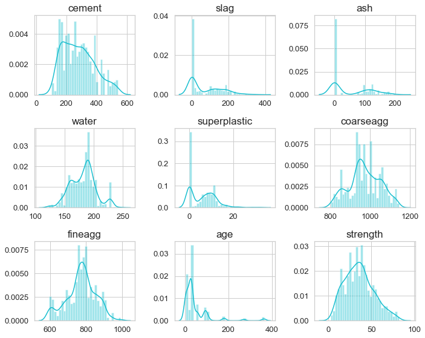

```python
col_names=DataFrame.columns.values.tolist()
sns.set(context='notebook',style='whitegrid', palette='dark',font='sans-serif',font_scale=1.2,color_codes=True)
fig, axes = plt.subplots(nrows=3, ncols=3)
count=0
for i in range (3):
    for j in range (3):
        col=col_names[count+j]
        sns.distplot(DataFrame[col].values,ax=axes[i][j],bins=30,color="tab:cyan")
        axes[i][j].set_title(col,fontsize=17)
        fig=plt.gcf()
        fig.set_size_inches(10,8)
        plt.tight_layout()
    count=count+j+1
```

### Understanding from distributions

- 'slag','ash','superplastc' and 'age' are right skewed.
- 'strength' and 'fineagg' are somewhat normally distributed.
- The distributions of 'water' and 'coarseagg' have 3 clusters.
- 'superplastic', 'fineagg' and 'ash' have 2 clusters.

## Measure of Skewness

```python
DataFrame.skew().to_frame('Skewness measure').T #for measure of skewness
```

|  | cement | slag | ash | water | superplastic | coarseagg | fineagg | age | strength |
| --- | --- | --- | --- | --- | --- | --- | --- | --- | --- |
| Skewness measure | 0.509481 | 0.800717 | 0.537354 | 0.074628 | 0.907203 | -0.04022 | -0.25301 | 3.269177 | 0.416977 |

## Checking presence of Outliers

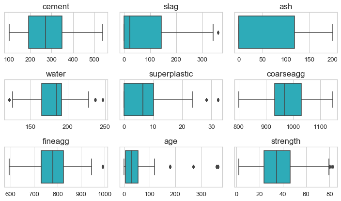

```python
col_names=DataFrame.columns.values.tolist()#column names
fig, axes = plt.subplots(nrows=3, ncols=3) #create subplots 9rows x 2columns
count=0
for i in range (3):
    for j in range (3):
        col=col_names[count+j]
        sns.boxplot(DataFrame[col].values,ax=axes[i][j],color="tab:cyan")
        axes[i][j].set_title(col,fontsize=17)
        fig=plt.gcf()
        fig.set_size_inches(10,6)
        plt.tight_layout()
    count=count+j+1
```

### Understanding from boxplots

- Prove the existance of outliers in 'water','superplastic','age' and 'slag' columns.
- Outliers also exist in 'fineagg' and 'strength' columns.
- 'slag','ash','superplastc' and 'age' are right skewed.
- The number of outliers is with respect to total rows in data, the outliers will not affect severely on the model performances; So the outliers are kept as it is.

## Pairplot of Features

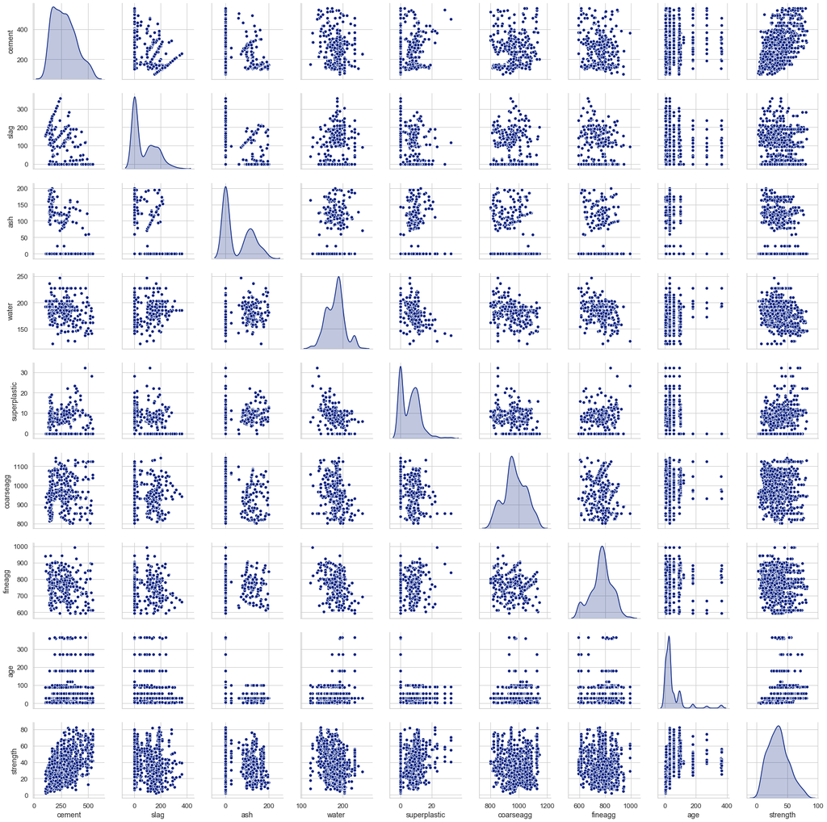

```python
sns.pairplot(DataFrame,diag_kind='kde')
```

### Understanding from pairplot

- Positive and negative correlation are present in multiple features.
- The analysis of diagonal can be used for cluster analysis, 'water' and 'coarseagg' have 3 clusters.
- 'superplastic', 'fineagg', 'ash' and 'slag' have 2 clusters.
- 'age' has 5 clusters.

## Corr plot of features

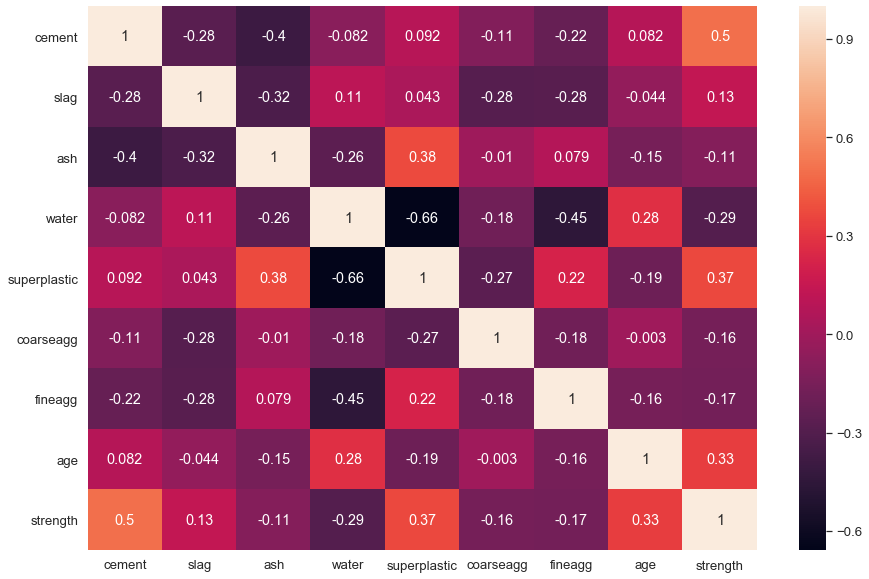

```python
plt.figure(figsize=(15,10)) #for adjusting figuresize
sns.heatmap(DataFrame.corr(),annot=True) #for correlation plot
```

### Understanding from Corrplot:

- Our objective is to predict the strength, if the features are highly correlated the results will not be accurate.
- 'cement' and 'strength' these columns are highly correlated(0.50) 50% to each other.
- the correlation between all other columns is very low to moderate(between -0.66 to 0.38).

## Scaling of Columns

```python
PCA_df=DataFrame.copy()
DataFrame_scaled = DataFrame.apply(zscore)
```

- Using zscore for scaling

## X,y,Train and Test split (70:30)

```python
X = DataFrame_scaled.drop('strength',axis=1) #independent dimensions
y = DataFrame_scaled['strength'] #selecting target column
```

```python
X_train,X_test,y_train,y_test = train_test_split(X, y, test_size=.30,random_state=1)#train test split 70:30
```

# Feature importance test

## Using Decision tree

```python
DTR=DecisionTreeRegressor() #Decision tree regressor
DTR.fit(X_train,y_train) #fit decision tree

importance = pd.DataFrame(DTR.feature_importances_,index = X_train.columns,columns=['Importance']) #Feature importance
importance #display importance
```

|  | Importance |
| --- | --- |
| cement | 0.351406 |
| slag | 0.096313 |
| ash | 0.012058 |
| water | 0.119653 |
| superplastic | 0.019643 |
| coarseagg | 0.034182 |
| fineagg | 0.033498 |
| age | 0.333247 |

## Using PCA

```python
X = PCA_df.drop('strength',axis=1) #independent dimensions
y = PCA_df['strength'] #selecting target column
Xscaled = X.apply(zscore) #Scaling with zscore
```

```python
pca = PCA() #PCA
pca.fit(Xscaled) #fit Scaled data into PCA
```

```
PCA(copy=True, iterated_power='auto', n_components=None, random_state=None,
    svd_solver='auto', tol=0.0, whiten=False)
```

```python
print(pca.explained_variance_) #Eigen Values
```

```
[2.2823152  1.41745097 1.34138135 1.01514445 0.95243269 0.7909634
 0.17801452 0.03007197]
```

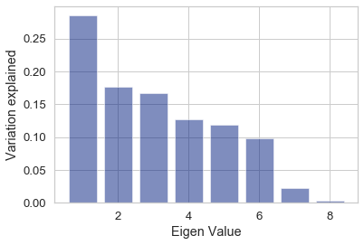

```python
plt.bar(list(range(1,9)),pca.explained_variance_ratio_,alpha=0.5, align='center') #bar plot of Eigen Values vs Variation explained
plt.ylabel('Variation explained')#set y label
plt.xlabel('Eigen Value')# set x label
plt.show()
```

### Understanding from feature importance test

- In Decision tree based feature importance test, feature wise importance is shown for the regression of strength.
- In PCA, it can be ssen that 6 features are able to cover more than 95% of variance in the data.

# Data Prepocessing

## Removing less significant columns using decision tree method

- Let the threshold of countribution in the prediction be 0.02, so 2 features should be removed.

```python
X = DataFrame_scaled.drop(['strength','superplastic','ash'],axis=1) #independent dimensions
y = DataFrame_scaled['strength'] #selecting target colum
```

## Train Test Split (70:30)

```python
X_train, X_test, y_train, y_test = train_test_split(X, y, test_size=0.3, random_state=1)#train test split 70:30
```

# Model building

## Ordinary Least Squared Regression

```python
model = sm.ols(formula='y ~ X', data=DataFrame_scaled) #Ordinary Least Squared Regression
fitted2 = model.fit() #fit OLS
fitted2.summary()#OLS summary
```

OLS Regression Results

| Dep. Variable: | y | R-squared: | 0.591 |
| --- | --- | --- | --- |
| Model: | OLS | Adj. R-squared: | 0.589 |
| Method: | Least Squares | F-statistic: | 246.5 |
| Date: | Sun, 08 Dec 2019 | Prob (F-statistic): | 1.04e-194 |
| Time: | 15:40:21 | Log-Likelihood: | -1001.0 |
| No. Observations: | 1030 | AIC: | 2016. |
| Df Residuals: | 1023 | BIC: | 2051. |
| Df Model: | 6 |  |  |
| Covariance Type: | nonrobust |  |  |

|  | coef | std err | t | P>\|t\| | [0.025 | 0.975] |
| --- | --- | --- | --- | --- | --- | --- |
| Intercept | -2.082e-17 | 0.020 | -1.04e-15 | 1.000 | -0.039 | 0.039 |
| X[0] | 0.3981 | 0.025 | 15.771 | 0.000 | 0.349 | 0.448 |
| X[1] | 0.1953 | 0.026 | 7.438 | 0.000 | 0.144 | 0.247 |
| X[2] | -0.5383 | 0.026 | -20.376 | 0.000 | -0.590 | -0.486 |
| X[3] | -0.2052 | 0.026 | -8.016 | 0.000 | -0.255 | -0.155 |
| X[4] | -0.2378 | 0.030 | -7.976 | 0.000 | -0.296 | -0.179 |
| X[5] | 0.4166 | 0.021 | 19.847 | 0.000 | 0.375 | 0.458 |

| Omnibus: | 4.424 | Durbin-Watson: | 1.871 |
| --- | --- | --- | --- |
| Prob(Omnibus): | 0.109 | Jarque-Bera (JB): | 4.496 |
| Skew: | -0.157 | Prob(JB): | 0.106 |
| Kurtosis: | 2.921 | Cond. No. | 3.00 |

Warnings:  
[1] Standard Errors assume that the covariance matrix of the errors is correctly specified.

- The Adjusted R2 is 0.589 i.e. 58% is goodness of fit of Ordinary Least Squared Regression

## Ridge Regression

```python
ridge = Ridge(alpha=.3,random_state=1) #Ridge Regression
ridge.fit(X_train,y_train) #Fit
predicted_ridge = ridge.predict(X_test) #Predict


T_rmse_ridge=np.sqrt(mean_squared_error(y_train,ridge.predict(X_train)))#Training mean squared error
Training_R2_ridge = r2_score(y_train,ridge.predict(X_train))#Training R2 score

RMSE_ridge=np.sqrt(mean_squared_error(y_test,predicted_ridge))#Test mean squared error
R2_ridge=r2_score(y_test, predicted_ridge)#Test R2 score

Scores = [('Mean Absolute Error',mean_absolute_error(y_train,ridge.predict(X_train)),'Mean Absolute Error',mean_absolute_error(y_test,predicted_ridge)),
      ('Mean Squared Error',mean_squared_error(y_train,ridge.predict(X_train)),'Mean Squared Error',mean_squared_error(y_test,predicted_ridge)),
      ('Root Mean Squared Error',T_rmse_ridge,'Root Mean Squared Error',RMSE_ridge),
      ('R2 Score',Training_R2_ridge,'R2 Score',R2_ridge)] #List of accuracy scores of all models

Scores = pd.DataFrame(Scores,columns=['Train Data','Score','Test Data','Score'])
Scores
```

|  | Train Data | Score | Test Data | Score |
| --- | --- | --- | --- | --- |
| 0 | Mean Absolute Error | 0.515295 | Mean Absolute Error | 0.509166 |
| 1 | Mean Squared Error | 0.418794 | Mean Squared Error | 0.397104 |
| 2 | Root Mean Squared Error | 0.647143 | Root Mean Squared Error | 0.630162 |
| 3 | R2 Score | 0.573163 | R2 Score | 0.619581 |

## Lasso Regression

```python
lasso = Lasso(alpha=0.1,random_state=1)#Lasso Regression
lasso.fit(X_train,y_train)#fit
predicted_lasso = lasso.predict(X_test) #Predict


RMSE_lasso=np.sqrt(mean_squared_error(y_test,predicted_lasso))#Test mean squared error
R2_lasso=r2_score(y_test, predicted_lasso)#Test R2 score
T_rmse_lasso=np.sqrt(mean_squared_error(y_train,lasso.predict(X_train)))#Training mean squared error
Training_R2_lasso = r2_score(y_train,lasso.predict(X_train))#Training R2 score



Scores = [('Mean Absolute Error',mean_absolute_error(y_train,lasso.predict(X_train)),'Mean Absolute Error',mean_absolute_error(y_test,predicted_lasso)),
      ('Mean Squared Error',mean_squared_error(y_train,lasso.predict(X_train)),'Mean Squared Error',mean_squared_error(y_test,predicted_lasso)),
      ('Root Mean Squared Error',T_rmse_lasso,'Root Mean Squared Error',RMSE_lasso),
      ('R2 Score',Training_R2_lasso,'R2 Score',R2_lasso)] #List of accuracy scores of all models

Scores = pd.DataFrame(Scores,columns=['Train Data','Score','Test Data','Score'])
Scores
```

|  | Train Data | Score | Test Data | Score |
| --- | --- | --- | --- | --- |
| 0 | Mean Absolute Error | 0.567249 | Mean Absolute Error | 0.607334 |
| 1 | Mean Squared Error | 0.492503 | Mean Squared Error | 0.529287 |
| 2 | Root Mean Squared Error | 0.701786 | Root Mean Squared Error | 0.727521 |
| 3 | R2 Score | 0.498038 | R2 Score | 0.492952 |

## Support Vector Regressor

```python
svr = SVR(C=1000,gamma='auto')  #Instantiate SVC
svr.fit(X_train,y_train) #Call the fit method of SVC to train the model or to learn the parameters of model
predicted_svr = svr.predict(X_test) #Predict



T_rmse_svr=np.sqrt(mean_squared_error(y_train,svr.predict(X_train)))#Training mean squared error
Training_R2_svr = r2_score(y_train,svr.predict(X_train))#Training R2 score

RMSE_svr=np.sqrt(mean_squared_error(y_test,predicted_svr))#Test mean squared error
R2_svr=r2_score(y_test, predicted_svr)#Test R2 score



Scores = [('Mean Absolute Error',mean_absolute_error(y_train,svr.predict(X_train)),'Mean Absolute Error',mean_absolute_error(y_test,predicted_svr)),
      ('Mean Squared Error',mean_squared_error(y_train,svr.predict(X_train)),'Mean Squared Error',mean_squared_error(y_test,predicted_svr)),
      ('Root Mean Squared Error',T_rmse_svr,'Root Mean Squared Error',RMSE_svr),
      ('R2 Score',Training_R2_svr,'R2 Score',R2_svr)] #List of accuracy scores of all models

Scores = pd.DataFrame(Scores,columns=['Train Data','Score','Test Data','Score'])
Scores
```

|  | Train Data | Score | Test Data | Score |
| --- | --- | --- | --- | --- |
| 0 | Mean Absolute Error | 0.113546 | Mean Absolute Error | 0.347337 |
| 1 | Mean Squared Error | 0.024294 | Mean Squared Error | 0.394118 |
| 2 | Root Mean Squared Error | 0.155864 | Root Mean Squared Error | 0.627788 |
| 3 | R2 Score | 0.975240 | R2 Score | 0.622441 |

## Decision Tree Regressor

```python
dTR = DecisionTreeRegressor(random_state=1) #Instantiate Decision Tree
dTR.fit(X_train, y_train) #Call the fit method of DT to train the model or to learn the parameters of model
predicted_dTR = dTR.predict(X_test) #Predict



T_rmse_dTR=np.sqrt(mean_squared_error(y_train,dTR.predict(X_train)))#Training mean squared error
Training_R2_dTR = r2_score(y_train,dTR.predict(X_train))#Training R2 score

RMSE_dTR=np.sqrt(mean_squared_error(y_test,predicted_dTR))#Test mean squared error
R2_dTR=r2_score(y_test, predicted_dTR)#Test R2 score

Scores = [('Mean Absolute Error',mean_absolute_error(y_train,dTR.predict(X_train)),'Mean Absolute Error',mean_absolute_error(y_test,predicted_dTR)),
      ('Mean Squared Error',mean_squared_error(y_train,dTR.predict(X_train)),'Mean Squared Error',mean_squared_error(y_test,predicted_dTR)),
      ('Root Mean Squared Error',T_rmse_dTR,'Root Mean Squared Error',RMSE_dTR),
      ('R2 Score',Training_R2_dTR,'R2 Score',R2_dTR)] #List of accuracy scores of all models

Scores = pd.DataFrame(Scores,columns=['Train Data','Score','Test Data','Score'])
Scores
```

|  | Train Data | Score | Test Data | Score |
| --- | --- | --- | --- | --- |
| 0 | Mean Absolute Error | 0.010204 | Mean Absolute Error | 0.253424 |
| 1 | Mean Squared Error | 0.005665 | Mean Squared Error | 0.149993 |
| 2 | Root Mean Squared Error | 0.075268 | Root Mean Squared Error | 0.387289 |
| 3 | R2 Score | 0.994226 | R2 Score | 0.856309 |

## Gradient Boosting Regressor

```python
GBR =GradientBoostingRegressor(random_state=1)#Decision Tree Regression
GBR.fit(X_train, y_train)#fit
predicted_GBR = GBR.predict(X_test) #predict



T_rmse_GBR=np.sqrt(mean_squared_error(y_train,GBR.predict(X_train)))#Training mean squared error
Training_R2_GBR = r2_score(y_train,GBR.predict(X_train))#Training R2 score

RMSE_GBR=np.sqrt(mean_squared_error(y_test,predicted_GBR))#Test mean squared error
R2_GBR=r2_score(y_test, predicted_GBR)#Test R2 score

Scores = [('Mean Absolute Error',mean_absolute_error(y_train,GBR.predict(X_train)),'Mean Absolute Error',mean_absolute_error(y_test,predicted_GBR)),
      ('Mean Squared Error',mean_squared_error(y_train,GBR.predict(X_train)),'Mean Squared Error',mean_squared_error(y_test,predicted_GBR)),
      ('Root Mean Squared Error',T_rmse_GBR,'Root Mean Squared Error',RMSE_GBR),
      ('R2 Score',Training_R2_GBR,'R2 Score',R2_GBR)] #List of accuracy scores of all models

Scores = pd.DataFrame(Scores,columns=['Train Data','Score','Test Data','Score'])
Scores
```

|  | Train Data | Score | Test Data | Score |
| --- | --- | --- | --- | --- |
| 0 | Mean Absolute Error | 0.169658 | Mean Absolute Error | 0.237125 |
| 1 | Mean Squared Error | 0.050400 | Mean Squared Error | 0.101989 |
| 2 | Root Mean Squared Error | 0.224499 | Root Mean Squared Error | 0.319357 |
| 3 | R2 Score | 0.948632 | R2 Score | 0.902296 |

## Adaptive Boosting Regressor

```python
ABR = AdaBoostRegressor(random_state=1)#Adaptive boosting Regression
ABR.fit(X_train, y_train)#fit
predicted_ABR = ABR.predict(X_test) #predict



T_rmse_ABR=np.sqrt(mean_squared_error(y_train,ABR.predict(X_train)))#Training mean squared error
Training_R2_ABR = r2_score(y_train,ABR.predict(X_train))#Training R2 score

RMSE_ABR=np.sqrt(mean_squared_error(y_test,predicted_ABR))#Test mean squared error
R2_ABR=r2_score(y_test, predicted_ABR)#Test R2 score

Scores = [('Mean Absolute Error',mean_absolute_error(y_train,ABR.predict(X_train)),'Mean Absolute Error',mean_absolute_error(y_test,predicted_ABR)),
      ('Mean Squared Error',mean_squared_error(y_train,ABR.predict(X_train)),'Mean Squared Error',mean_squared_error(y_test,predicted_ABR)),
      ('Root Mean Squared Error',T_rmse_ABR,'Root Mean Squared Error',RMSE_ABR),
      ('R2 Score',Training_R2_ABR,'R2 Score',R2_ABR)] #List of accuracy scores of all models

Scores = pd.DataFrame(Scores,columns=['Train Data','Score','Test Data','Score'])
Scores
```

|  | Train Data | Score | Test Data | Score |
| --- | --- | --- | --- | --- |
| 0 | Mean Absolute Error | 0.351642 | Mean Absolute Error | 0.411406 |
| 1 | Mean Squared Error | 0.176077 | Mean Squared Error | 0.245954 |
| 2 | Root Mean Squared Error | 0.419615 | Root Mean Squared Error | 0.495937 |
| 3 | R2 Score | 0.820542 | R2 Score | 0.764381 |

## Bagging Regressor

```python
BAGG = BaggingRegressor(random_state=1)#Bagging Regression
BAGG  = BAGG.fit(X_train,y_train)#fit
predicted_BAGG = BAGG.predict(X_test) #predict

T_rmse_BAGG=np.sqrt(mean_squared_error(y_train,BAGG.predict(X_train)))#Training mean squared error
Training_R2_BAGG = r2_score(y_train,BAGG.predict(X_train))#Training R2 score

RMSE_BAGG=np.sqrt(mean_squared_error(y_test,predicted_BAGG))#Test mean squared error
R2_BAGG=r2_score(y_test, predicted_BAGG)#Test R2 score

Scores = [('Mean Absolute Error',mean_absolute_error(y_train,BAGG.predict(X_train)),'Mean Absolute Error',mean_absolute_error(y_test,predicted_BAGG)),
      ('Mean Squared Error',mean_squared_error(y_train,BAGG.predict(X_train)),'Mean Squared Error',mean_squared_error(y_test,predicted_BAGG)),
      ('Root Mean Squared Error',T_rmse_BAGG,'Root Mean Squared Error',RMSE_BAGG),
      ('R2 Score',Training_R2_BAGG,'R2 Score',R2_BAGG)] #List of accuracy scores of all models

Scores = pd.DataFrame(Scores,columns=['Train Data','Score','Test Data','Score'])
Scores
```

|  | Train Data | Score | Test Data | Score |
| --- | --- | --- | --- | --- |
| 0 | Mean Absolute Error | 0.098299 | Mean Absolute Error | 0.234823 |
| 1 | Mean Squared Error | 0.025988 | Mean Squared Error | 0.116690 |
| 2 | Root Mean Squared Error | 0.161209 | Root Mean Squared Error | 0.341599 |
| 3 | R2 Score | 0.973512 | R2 Score | 0.888213 |

## Random Forest Regressor

```python
Rforest = RandomForestRegressor(n_estimators = 100, random_state=1)#Instantiate Random Forest Classifier
Rforest = Rforest.fit(X_train, y_train) #Call the fit method of Random Forest Classifier to train the model or to learn the parameters of model
predicted_Rforest = Rforest.predict(X_test) #Predict


T_rmse_Rforest=np.sqrt(mean_squared_error(y_train,Rforest.predict(X_train)))#Training mean squared error
Training_R2_Rforest = r2_score(y_train,Rforest.predict(X_train))#Training R2 score

RMSE_Rforest=np.sqrt(mean_squared_error(y_test,predicted_Rforest))#Test mean squared error
R2_Rforest=r2_score(y_test, predicted_Rforest)#Test R2 score

Scores = [('Mean Absolute Error',mean_absolute_error(y_train,Rforest.predict(X_train)),'Mean Absolute Error',mean_absolute_error(y_test,predicted_Rforest)),
      ('Mean Squared Error',mean_squared_error(y_train,Rforest.predict(X_train)),'Mean Squared Error',mean_squared_error(y_test,predicted_Rforest)),
      ('Root Mean Squared Error',T_rmse_Rforest,'Root Mean Squared Error',RMSE_Rforest),
      ('R2 Score',Training_R2_Rforest,'R2 Score',R2_Rforest)] #List of accuracy scores of all models

Scores = pd.DataFrame(Scores,columns=['Train Data','Score','Test Data','Score'])
Scores
```

|  | Train Data | Score | Test Data | Score |
| --- | --- | --- | --- | --- |
| 0 | Mean Absolute Error | 0.085582 | Mean Absolute Error | 0.224496 |
| 1 | Mean Squared Error | 0.017916 | Mean Squared Error | 0.102113 |
| 2 | Root Mean Squared Error | 0.133852 | Root Mean Squared Error | 0.319552 |
| 3 | R2 Score | 0.981740 | R2 Score | 0.902177 |

## Regression with Polynomial Features

```python
poly = PolynomialFeatures(degree = 4, interaction_only=True)#create polynomial features with degree=4
X_poly = poly.fit_transform(Xscaled)#fit
X_train, X_test, y_train, y_test = train_test_split(X_poly, y, test_size=0.25, random_state=1)#train test split
```

### Ridge Regression with Poly = 4

```python
ridge = Ridge(alpha=.3,random_state=1)#Ridge Regression
ridge.fit(X_train,y_train)#fit
predicted_ridge=ridge.predict(X_test)#predict


T_rmse_pridge=np.sqrt(mean_squared_error(y_train,ridge.predict(X_train)))#Training mean squared error
Training_R2_pridge = r2_score(y_train,ridge.predict(X_train))#Training R2 score

RMSE_pridge=np.sqrt(mean_squared_error(y_test,predicted_ridge))#Test mean squared error
R2_pridge=r2_score(y_test, predicted_ridge)#Test R2 score

Scores = [('Mean Absolute Error',mean_absolute_error(y_train,ridge.predict(X_train)),'Mean Absolute Error',mean_absolute_error(y_test,predicted_ridge)),
      ('Mean Squared Error',mean_squared_error(y_train,ridge.predict(X_train)),'Mean Squared Error',mean_squared_error(y_test,predicted_ridge)),
      ('Root Mean Squared Error',T_rmse_pridge,'Root Mean Squared Error',RMSE_pridge),
      ('R2 Score',Training_R2_pridge,'R2 Score',R2_pridge)] #List of accuracy scores of all models

Scores = pd.DataFrame(Scores,columns=['Train Data','Score','Test Data','Score'])
Scores
```

|  | Train Data | Score | Test Data | Score |
| --- | --- | --- | --- | --- |
| 0 | Mean Absolute Error | 0.301301 | Mean Absolute Error | 0.395437 |
| 1 | Mean Squared Error | 0.144566 | Mean Squared Error | 0.272872 |
| 2 | Root Mean Squared Error | 0.380218 | Root Mean Squared Error | 0.522372 |
| 3 | R2 Score | 0.850967 | R2 Score | 0.749587 |

### Lasso Regression with Poly = 4

```python
lasso = Lasso(alpha=0.01,random_state=1)#Lasso Regression
lasso.fit(X_train,y_train)#fit
predicted_lasso = lasso.predict(X_test) #Predict


RMSE_plasso=np.sqrt(mean_squared_error(y_test,predicted_lasso))#Test mean squared error
R2_plasso=r2_score(y_test, predicted_lasso)#Test R2 score
T_rmse_plasso=np.sqrt(mean_squared_error(y_train,lasso.predict(X_train)))#Training mean squared error
Training_R2_plasso = r2_score(y_train,lasso.predict(X_train))#Training R2 score


Scores = [('Mean Absolute Error',mean_absolute_error(y_train,lasso.predict(X_train)),'Mean Absolute Error',mean_absolute_error(y_test,predicted_lasso)),
      ('Mean Squared Error',mean_squared_error(y_train,lasso.predict(X_train)),'Mean Squared Error',mean_squared_error(y_test,predicted_lasso)),
      ('Root Mean Squared Error',T_rmse_plasso,'Root Mean Squared Error',RMSE_plasso),
      ('R2 Score',Training_R2_plasso,'R2 Score',R2_plasso)] #List of accuracy scores of all models

Scores = pd.DataFrame(Scores,columns=['Train Data','Score','Test Data','Score'])
Scores
```

|  | Train Data | Score | Test Data | Score |
| --- | --- | --- | --- | --- |
| 0 | Mean Absolute Error | 0.346657 | Mean Absolute Error | 0.406322 |
| 1 | Mean Squared Error | 0.197624 | Mean Squared Error | 0.263184 |
| 2 | Root Mean Squared Error | 0.444549 | Root Mean Squared Error | 0.513014 |
| 3 | R2 Score | 0.796269 | R2 Score | 0.758478 |

# All Model Scores

```python
Scores = [('Ridge Regression',Training_R2_ridge,R2_ridge,T_rmse_ridge,RMSE_ridge),
      ('Lasso Regression',Training_R2_lasso,R2_lasso,T_rmse_lasso,RMSE_lasso),
      ('Support Vector Regressor',Training_R2_svr,R2_svr,T_rmse_svr,RMSE_svr),
      ('Decision Tree Regressor',Training_R2_dTR,R2_dTR,T_rmse_dTR,RMSE_dTR),
      ('Gradient Boosting Regressor',Training_R2_GBR,R2_GBR,T_rmse_GBR,RMSE_GBR),
      ('Adaptive Boosting Regressor',Training_R2_ABR,R2_ABR,T_rmse_ABR,RMSE_ABR),
      ('Bagging Regressor',Training_R2_BAGG,R2_BAGG,T_rmse_BAGG,RMSE_BAGG),
      ('Ridge Regression with Poly = 4',Training_R2_pridge,R2_pridge,T_rmse_pridge,RMSE_pridge),
      ('Lasso Regression with Poly = 4',Training_R2_plasso,R2_plasso,T_rmse_plasso,RMSE_plasso),
      ('Random Forest Regressor',Training_R2_Rforest,R2_Rforest,T_rmse_Rforest,RMSE_Rforest)] #List of accuracy scores of all models

Scores = pd.DataFrame(Scores,columns=['Model','R2 Score train','R2 Score test','RMSE train','RMSE test']) #Conversion of list to dataframe
Sorted=Scores.sort_values(by='R2 Score test',ascending=True) #Sort values in descending manner
Sorted
```

|  | Model | R2 Score train | R2 Score test | RMSE train | RMSE test |
| --- | --- | --- | --- | --- | --- |
| 1 | Lasso Regression | 0.498038 | 0.492952 | 0.701786 | 0.727521 |
| 0 | Ridge Regression | 0.573163 | 0.619581 | 0.647143 | 0.630162 |
| 2 | Support Vector Regressor | 0.975240 | 0.622441 | 0.155864 | 0.627788 |
| 7 | Ridge Regression with Poly = 4 | 0.850967 | 0.749587 | 0.380218 | 0.522372 |
| 8 | Lasso Regression with Poly = 4 | 0.796269 | 0.758478 | 0.444549 | 0.513014 |
| 5 | Adaptive Boosting Regressor | 0.820542 | 0.764381 | 0.419615 | 0.495937 |
| 3 | Decision Tree Regressor | 0.994226 | 0.856309 | 0.075268 | 0.387289 |
| 6 | Bagging Regressor | 0.973512 | 0.888213 | 0.161209 | 0.341599 |
| 9 | Random Forest Regressor | 0.981740 | 0.902177 | 0.133852 | 0.319552 |
| 4 | Gradient Boosting Regressor | 0.948632 | 0.902296 | 0.224499 | 0.319357 |

## Comments on Models

- Above Score are Sorted on the basis of R2 Test Score
- Adjusted R2 scores are more effecient in eveluating goodness of fit. As there is not a builtin function to calculate adjusted R2, R2 scoring is used to assess the performance of models.
- Along with R2, Root Mean Squared Error(RMSE), Mean Squared Error(MSE) and Mean Absolute Error(MAE) are used to assess the performance of model.
- R2 Scores and RMSE are inversely proportional i.e. increase in R2 will reduce RMSE.
- The scores are in ascending order.
- The Linear regression techniques are producing 49% to 75% R2 score even with Polynomials. So non linear models are preferable for achieving the goal of prediction.
- Gradient boosting,Random forest,Bagging and Decision tree regressor are performing well in terms of regression as these models are able to achieve R2 scores >=85%
- Though these models are able to produce 85% score, these models are overfitting.
- The model with lowest RMSE should be preferred. In this analysis it is Gradient Boosting Regressor.
- Model comparison is shown below in line graph.

### Comparison of Model R2 Scores

### Model Scores

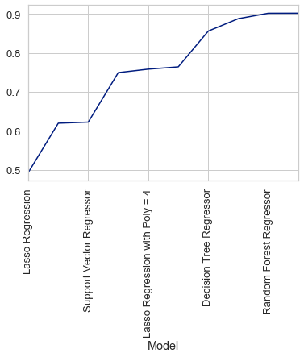

```python
Sorted.plot(x='Model', y='R2 Score test', legend=False,rot=90)#plot
plt.show()#display plot
```

### Train vs Test R2 comparison

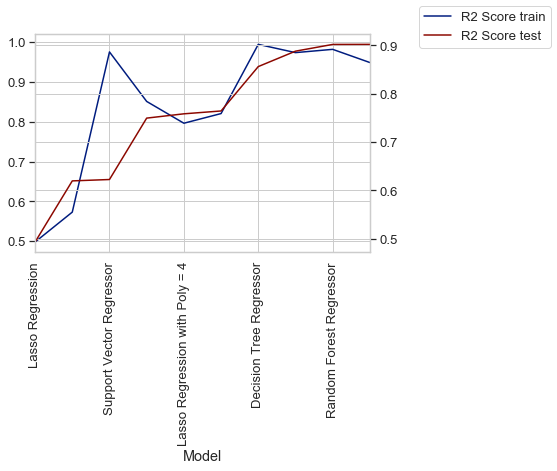

```python
ax = Sorted.plot(x='Model', y='R2 Score train', legend=False,rot=90)#plot
ax2 = ax.twinx()#axis object
Sorted.plot(x='Model', y='R2 Score test', ax=ax2, legend=False, color="r")#plot
ax.figure.legend()#legend
ax.legend(bbox_to_anchor=(0.8,0), bbox_transform=fig.transFigure)#legend
plt.show()#display plot
```

# Bootstrapping at 95% confidence interval

- Boostrapping will help in calculating how much variance is TRULY captured in 95% Confidence interval.
- For evaluating the regressors, R2 Scores are used.

## Gradient Boosting Regressor

```python
import warnings
warnings.simplefilter(action='ignore', category=FutureWarning)

values=DataFrame_scaled.values
from sklearn.utils import resample
# configure bootstrap
n_iterations = 1000              # Number of bootstrap samples to create
n_size = int(len(DataFrame_scaled) * 0.50)    # picking only 50 % of the given data in every bootstrap sample

# run bootstrap
stats = list()
for i in range(n_iterations):
    # prepare train and test sets
    train = resample(values, n_samples=n_size)  # Sampling with replacement
    test = np.array([x for x in values if x.tolist() not in train.tolist()])  # picking rest of the data not considered in sample
    # fit model
    model = GradientBoostingRegressor(alpha= 0.1, learning_rate= 0.1, max_depth= 4, max_features= 2, n_estimators=490,
                                random_state= 1)
    model.fit(train[:,:-1], train[:,-1])
    # evaluate model
    predictions = model.predict(test[:,:-1])
    score = r2_score(test[:,-1], predictions)    # caution, overall accuracy score can mislead when classes are imbalanced
    stats.append(score)
```

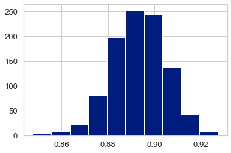

```
95.0 confidence interval 86.9% and 91.4%
```

```python
# plot scores
plt.hist(stats)
plt.show()
# confidence intervals
alpha = 0.95 # for 95% confidence
p = ((1.0-alpha)/2.0) * 100 # tail regions on right and left .25 on each side indicated by P value (border)
lower = max(0.0, np.percentile(stats, p))
p = (alpha+((1.0-alpha)/2.0)) * 100
upper = min(1.0, np.percentile(stats, p))
print('%.1f confidence interval %.1f%% and %.1f%%' % (alpha*100, lower*100, upper*100))
```

## Random Forest Regressor

```python
import warnings
warnings.simplefilter(action='ignore', category=FutureWarning)

values=DataFrame_scaled.values
from sklearn.utils import resample
# configure bootstrap
n_iterations = 1000              # Number of bootstrap samples to create
n_size = int(len(DataFrame_scaled) * 0.50)    # picking only 50 % of the given data in every bootstrap sample

# run bootstrap
stats = list()
for i in range(n_iterations):
    # prepare train and test sets
    train = resample(values, n_samples=n_size)  # Sampling with replacement
    test = np.array([x for x in values if x.tolist() not in train.tolist()])  # picking rest of the data not considered in sample
    # fit model
    model = RandomForestRegressor(random_state= 1)
    model.fit(train[:,:-1], train[:,-1])
    # evaluate model
    predictions = model.predict(test[:,:-1])
    score = r2_score(test[:,-1], predictions)    # caution, overall accuracy score can mislead when classes are imbalanced
    stats.append(score)
```

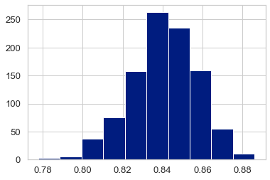

```
95.0 confidence interval 80.7% and 86.8%
```

```python
# plot scores
plt.hist(stats)
plt.show()
# confidence intervals
alpha = 0.95 # for 95% confidence
p = ((1.0-alpha)/2.0) * 100 # tail regions on right and left .25 on each side indicated by P value (border)
lower = max(0.0, np.percentile(stats, p))
p = (alpha+((1.0-alpha)/2.0)) * 100
upper = min(1.0, np.percentile(stats, p))
print('%.1f confidence interval %.1f%% and %.1f%%' % (alpha*100, lower*100, upper*100))
```

# Hyperparameter Tuning

- Using Parameter Tuning, the main objective is to reduce overfitting in models.
- Also, to improve the model performance.
- To improve model scores, following models are chosen at random from above models:

  1.GradientBoostingRegressor  
  2.RandomForestRegressor  
  3.SVR  
  4.DecisionTreeRegressor

## Train, Test and Validation Split (60/20/20)

```python
X_train, X_test, y_train, y_test = train_test_split(X, y, test_size=0.2, random_state=1)# 80:20
X_train, X_val, y_train, y_val = train_test_split(X_train, y_train, test_size=0.2, random_state=1)#60:20 in total 60:20:20
```

## Pipeline and Crossvalidation using gridsearch

### Gradient boosting Regressor with GridSearchCV

```python
GBR = GradientBoostingRegressor()#Gradient boosting
param_grid = {'alpha':np.arange(0.1,1.0),'n_estimators':np.arange(100,500,10),'max_depth':np.arange(3,8),
              'max_features':np.arange(2,5),'random_state':[1],'learning_rate':np.arange(0.1,1.0)} #parameters to be iterated

kfold=KFold(n_splits=6, shuffle=True, random_state=1)#LOOCV Kfold
grid = GridSearchCV(GBR , param_grid = param_grid, cv = kfold)#GridSearchCV
grid.fit(X_train, y_train) #fit training data

print('\033[1m''->'*63)
print(" Best parameters: ", grid.best_params_) #best parameters from above grid
print('\033[1m''-'*40)
print(" Best cross-validation accuracy: {:.2f}".format(grid.best_score_))
print(" Train set score: {:.2f}". format(grid.score(X_train, y_train)))
print(" Validation set score: {:.2f}". format(grid.score(X_val, y_val)))
print('\033[1m''->'*63)
```

```
->->->->->->->->->->->->->->->->->->->->->->->->->->->->->->->->->->->->->->->->->->->->->->->->->->->->->->->->->->->->->->->
 Best parameters:  {'alpha': 0.1, 'learning_rate': 0.1, 'max_depth': 4, 'max_features': 2, 'n_estimators': 490, 'random_state': 1}
----------------------------------------
 Best cross-validation accuracy: 0.92
 Train set score: 0.99
 Validation set score: 0.90
->->->->->->->->->->->->->->->->->->->->->->->->->->->->->->->->->->->->->->->->->->->->->->->->->->->->->->->->->->->->->->->
```

```python
GBR = GradientBoostingRegressor(alpha= 0.1, learning_rate= 0.1, max_depth= 4, max_features= 2, n_estimators=490,
                                random_state= 1) #GradientBoostingRegressor
GBR.fit(X_train,y_train) #fit

Training_score_GBR=GBR.score(X_train, y_train) #Training Score
Validation_score_GBR=GBR.score(X_val,y_val) #Validation Score
Test_score_GBR=GBR.score(X_test,y_test) #Test Score



print('\033[1m''->'*63)
print(" Train set score: {:.2f}". format(Training_score_GBR))
print(" Validation set score: {:.2f}". format(Validation_score_GBR))
print(" Test set score: {:.2f}". format(Test_score_GBR))
print('\033[1m''->'*63)
```

```
->->->->->->->->->->->->->->->->->->->->->->->->->->->->->->->->->->->->->->->->->->->->->->->->->->->->->->->->->->->->->->->
 Train set score: 0.99
 Validation set score: 0.90
 Test set score: 0.93
->->->->->->->->->->->->->->->->->->->->->->->->->->->->->->->->->->->->->->->->->->->->->->->->->->->->->->->->->->->->->->->
```

### RandomForest Regressor with GridSearchCV

```python
RFR = RandomForestRegressor()#Random Forest Regressor
param_grid = {'n_estimators': np.arange(10,500,10),'max_depth': np.arange(1, 6),'random_state':[1]} #parameters to be iterated

kfold=KFold(n_splits=6, shuffle=True, random_state=1)#LOOCV Kfold
grid = GridSearchCV(RFR , param_grid = param_grid, cv = kfold)#GridSearchCV
grid.fit(X_train, y_train) #fit training data

print('\033[1m''->'*63)
print(" Best parameters: ", grid.best_params_) #best parameters from above grid
print('\033[1m''-'*40)
print(" Best cross-validation accuracy: {:.2f}".format(grid.best_score_))
print(" Train set score: {:.2f}". format( grid.score(X_train, y_train)))
print(" Validation set score: {:.2f}". format(grid.score(X_val, y_val)))
print('\033[1m''->'*63)
```

```
->->->->->->->->->->->->->->->->->->->->->->->->->->->->->->->->->->->->->->->->->->->->->->->->->->->->->->->->->->->->->->->
 Best parameters:  {'max_depth': 5, 'n_estimators': 290, 'random_state': 1}
----------------------------------------
 Best cross-validation accuracy: 0.82
 Train set score: 0.88
 Validation set score: 0.81
->->->->->->->->->->->->->->->->->->->->->->->->->->->->->->->->->->->->->->->->->->->->->->->->->->->->->->->->->->->->->->->
```

```python
RFR =  RandomForestRegressor(max_depth= 5, n_estimators=290,random_state= 1)#RandomForestRegressor
RFR.fit(X_train,y_train) #fit

Training_score_RFR=RFR.score(X_train, y_train)#Training Score
Validation_score_RFR=RFR.score(X_val,y_val)#Validation Score
Test_score_RFR=RFR.score(X_test,y_test)#Test Score



print('\033[1m''->'*63)
print(" Train set score: {:.2f}". format(Training_score_RFR))
print(" Validation set score: {:.2f}". format(Validation_score_RFR))
print(" Test set score: {:.2f}". format(Test_score_RFR))
print('\033[1m''->'*63)
```

```
->->->->->->->->->->->->->->->->->->->->->->->->->->->->->->->->->->->->->->->->->->->->->->->->->->->->->->->->->->->->->->->
 Train set score: 0.88
 Validation set score: 0.81
 Test set score: 0.83
->->->->->->->->->->->->->->->->->->->->->->->->->->->->->->->->->->->->->->->->->->->->->->->->->->->->->->->->->->->->->->->
```

### Support Vector Regressor with GridSearchCV

```python
svr = SVR()#Support Vector Regressor

param_grid = {'C': [0.001,0.01,0.1,4,10], 'gamma': [0.001,0.01,0.1,1], 'kernel':['rbf'],'degree':[1,2,3,4,5],
              'coef0':[0.0,0.1,0.2,0.3,0.4,0.5]} #parameters to be iterated

kfold=KFold(n_splits=6, shuffle=True, random_state=1)#LOOCV Kfold

grid = GridSearchCV(svr , param_grid = param_grid, cv = kfold) #GridSearchCV
grid.fit(X_train, y_train) #fit training data

print('\033[1m''->'*63)
print(" Best parameters: ", grid.best_params_) #best parameters from above grid
print('\033[1m''-'*40)
print(" Best cross-validation accuracy: {:.2f}".format(grid.best_score_))
print(" Train set score: {:.2f}". format( grid.score(X_train, y_train)))
print(" Validation set score: {:.2f}". format(grid.score(X_val, y_val)))
print('\033[1m''->'*63)
```

```
->->->->->->->->->->->->->->->->->->->->->->->->->->->->->->->->->->->->->->->->->->->->->->->->->->->->->->->->->->->->->->->
 Best parameters:  {'C': 10, 'coef0': 0.0, 'degree': 1, 'gamma': 0.1, 'kernel': 'rbf'}
----------------------------------------
 Best cross-validation accuracy: 0.85
 Train set score: 0.91
 Validation set score: 0.87
->->->->->->->->->->->->->->->->->->->->->->->->->->->->->->->->->->->->->->->->->->->->->->->->->->->->->->->->->->->->->->->
```

```python
svr1 = SVR(C= 10, coef0= 0.0, degree= 1, gamma= 0.1, kernel= 'rbf') #SVR
svr1.fit(X_train,y_train) #fit


Training_score_svr1=svr1.score(X_train, y_train)#Training Score
Validation_score_svr1=svr1.score(X_val,y_val)#Validation Score
Test_score_svr1=svr1.score(X_test,y_test)#Test Score



print('\033[1m''->'*63)
print(" Train set score: {:.2f}". format(svr1.score(X_train, y_train)))
print(" Validation set score: {:.2f}". format(svr1.score(X_val,y_val)))
print(" Test set score: {:.2f}". format(svr1.score(X_test,y_test)))
print('\033[1m''->'*63)
```

```
->->->->->->->->->->->->->->->->->->->->->->->->->->->->->->->->->->->->->->->->->->->->->->->->->->->->->->->->->->->->->->->
 Train set score: 0.91
 Validation set score: 0.87
 Test set score: 0.87
->->->->->->->->->->->->->->->->->->->->->->->->->->->->->->->->->->->->->->->->->->->->->->->->->->->->->->->->->->->->->->->
```

### Decision Tree Regressor with RandomizedSearchCV

```python
DTR = DecisionTreeRegressor()#Decision Tree regressor

param_grid = {'max_depth': np.arange(3, 20),'criterion' : ['mse'],'max_features':np.arange(1,4),'splitter':['best','random'],
             'random_state' : [1]} #parameters to be iterated


kfold=KFold(n_splits=6, shuffle=True, random_state=1)#LOOCV Kfold
grid = RandomizedSearchCV( DTR, param_distributions = param_grid, n_iter=50,cv = kfold) #RandomCV
grid.fit(X_train, y_train) #fit training data


print('\033[1m''->'*63)
print(" Best parameters: ", grid.best_params_) #Random best parameters from 50 iterations
print('\033[1m''-'*40)
print(" Best cross-validation accuracy: {:.2f}".format(grid.best_score_))
print(" Train set score: {:.2f}". format( grid.score(X_train, y_train)))
print(" Validation set score: {:.2f}". format(grid.score(X_val, y_val)))
print('\033[1m''->'*63)
```

```
->->->->->->->->->->->->->->->->->->->->->->->->->->->->->->->->->->->->->->->->->->->->->->->->->->->->->->->->->->->->->->->
 Best parameters:  {'splitter': 'best', 'random_state': 1, 'max_features': 3, 'max_depth': 13, 'criterion': 'mse'}
----------------------------------------
 Best cross-validation accuracy: 0.78
 Train set score: 0.99
 Validation set score: 0.74
->->->->->->->->->->->->->->->->->->->->->->->->->->->->->->->->->->->->->->->->->->->->->->->->->->->->->->->->->->->->->->->
```

```python
DTR=DecisionTreeRegressor(splitter='best', max_features= 3, max_depth=16, criterion= 'mse',random_state=1)#Decision Tree regressor
DTR.fit(X_train,y_train) #fit


Training_score_dtr=DTR.score(X_train, y_train)#Training Score
Validation_score_dtr=DTR.score(X_val,y_val)#Validation Score
Test_score_dtr=DTR.score(X_test,y_test)#Test Score



print('\033[1m''->'*63)
print(" Train set score: {:.2f}". format(Training_score_dtr))
print(" Validation set score: {:.2f}". format(Validation_score_dtr))
print(" Test set score: {:.2f}". format(Test_score_dtr))
print('\033[1m''->'*63)
```

```
->->->->->->->->->->->->->->->->->->->->->->->->->->->->->->->->->->->->->->->->->->->->->->->->->->->->->->->->->->->->->->->
 Train set score: 1.00
 Validation set score: 0.79
 Test set score: 0.87
->->->->->->->->->->->->->->->->->->->->->->->->->->->->->->->->->->->->->->->->->->->->->->->->->->->->->->->->->->->->->->->
```

```python
Scores = [('Support Vector Regressor',Training_score_svr1,Validation_score_svr1,Test_score_svr1),
      ('Decision Tree Regressor',Training_score_dtr,Validation_score_dtr,Test_score_dtr),
      ('Gradient Boosting Regressor',Training_score_GBR,Validation_score_GBR,Test_score_GBR),
      ('Random Forest Regressor',Training_score_RFR,Validation_score_RFR,Test_score_RFR)] #List of accuracy scores of all models

Scores = pd.DataFrame(Scores,columns=['Model','Train Score','Validation Score','Test Score']) #Conversion of list to dataframe
Sorted=Scores.sort_values(by='Test Score',ascending=False) #Sort values in descending manner
Sorted
```

|  | Model | Train Score | Validation Score | Test Score |
| --- | --- | --- | --- | --- |
| 2 | Gradient Boosting Regressor | 0.994742 | 0.902404 | 0.928155 |
| 0 | Support Vector Regressor | 0.911168 | 0.870341 | 0.872863 |
| 1 | Decision Tree Regressor | 0.997084 | 0.790434 | 0.865463 |
| 3 | Random Forest Regressor | 0.882964 | 0.811164 | 0.827100 |

# Cluster Analysis using Kmeans

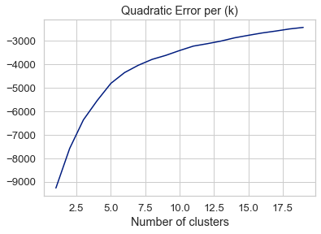

```python
from sklearn.cluster import KMeans
k = range(1, 20)
kmeans = [KMeans(n_clusters=i) for i in k]
score = [kmeans[i].fit(DataFrame_scaled).score(DataFrame_scaled) for i in range(len(kmeans))]
plt.plot(k,score)
plt.xlabel('Number of clusters')
plt.title('Quadratic Error per (k)')
plt.show()
```

- From above plot, it can be seen that 5 cluster can be chosen as efficient.
- In Pairplot(Section 2.8) it can be observed that maximum number of clusters is 5 as age column has 5 peaks.

```python
kmeans = KMeans(n_clusters=5,random_state=1) #kmeans with 5 clusters
kmeans.fit(DataFrame_scaled)#fit
DataFrame_scaled['cluster'] = kmeans.labels_#add clusters to dataframe
```

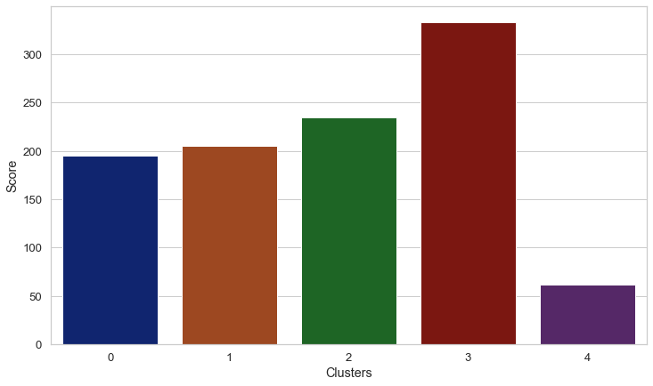

```python
plt.figure(figsize=(12,7)) #plot cluster distribution
axis = sns.barplot(x=np.arange(0,5,1),y=DataFrame_scaled.groupby(['cluster']).count()['strength'].values)
x=axis.set_xlabel("Clusters")
x=axis.set_ylabel("Score")
```

```python
cluster_data = list(DataFrame_scaled.groupby(['cluster']).count()['strength'].values)#Clusterwise data
```

```python
cluster_0=DataFrame_scaled[DataFrame_scaled['cluster']==cluster_data.index(sorted(cluster_data)[1])]#cluster 0 data
cluster_1=DataFrame_scaled[DataFrame_scaled['cluster']==cluster_data.index(sorted(cluster_data)[2])]#cluster 1 data
cluster_2=DataFrame_scaled[DataFrame_scaled['cluster']==cluster_data.index(sorted(cluster_data)[3])]#cluster 2 data
cluster_3=DataFrame_scaled[DataFrame_scaled['cluster']==cluster_data.index(sorted(cluster_data)[4])]#cluster 3 data
cluster_4=DataFrame_scaled[DataFrame_scaled['cluster']==cluster_data.index(sorted(cluster_data)[0])]#cluster 4 data
```

# Cluster wise model building

## Cluster 1

```python
X = cluster_0.drop(['strength','superplastic','ash','cluster','coarseagg'],axis=1) #independent dimensions
y = cluster_0['strength'] #selecting target colum
```

```python
X_train, X_test, y_train, y_test = train_test_split(X, y, test_size=0.3, random_state=1) #train test split
```

```python
DTR=DecisionTreeRegressor()#Decision Tree regressor
DTR.fit(X_train,y_train) #fit
importance = pd.DataFrame(DTR.feature_importances_,index = X_train.columns,columns=['Importance'])#importance
importance
```

|  | Importance |
| --- | --- |
| cement | 0.555607 |
| slag | 0.000672 |
| water | 0.052309 |
| fineagg | 0.048402 |
| age | 0.343010 |

```python
BAGG = BaggingRegressor(random_state=1,n_estimators=500)#BaggingRegressor
BAGG  = BAGG.fit(X_train,y_train)#fit
predicted_BAGG = BAGG.predict(X_test) #predict



T_rmse=np.sqrt(mean_squared_error(y_train,BAGG.predict(X_train)))#Training mean squared error
Training_R2 = r2_score(y_train,BAGG.predict(X_train))#Training R2 score
RMSE_BAGG=np.sqrt(mean_squared_error(y_test,predicted_BAGG))#Test mean squared error
R2_cluster_1=r2_score(y_test, predicted_BAGG)#Test R2 score

Scores = [('Mean Absolute Error',mean_absolute_error(y_train,BAGG.predict(X_train)),'Mean Absolute Error',mean_absolute_error(y_test,predicted_BAGG)),
      ('Mean Squared Error',mean_squared_error(y_train,BAGG.predict(X_train)),'Mean Squared Error',mean_squared_error(y_test,predicted_BAGG)),
      ('Root Mean Squared Error',T_rmse,'Root Mean Squared Error',RMSE_BAGG),
      ('R2 Score',Training_R2,'R2 Score',R2_cluster_1)] #List of accuracy scores of all models

Scores = pd.DataFrame(Scores,columns=['Train Data','Score','Test Data','Score'])
Scores
```

|  | Train Data | Score | Test Data | Score |
| --- | --- | --- | --- | --- |
| 0 | Mean Absolute Error | 0.074260 | Mean Absolute Error | 0.175216 |
| 1 | Mean Squared Error | 0.013857 | Mean Squared Error | 0.054369 |
| 2 | Root Mean Squared Error | 0.117715 | Root Mean Squared Error | 0.233172 |
| 3 | R2 Score | 0.977773 | R2 Score | 0.920261 |

## Cluster 2

```python
X = cluster_1.drop(['strength','cluster'],axis=1) #independent dimensions
y = cluster_1['strength'] #selecting target colum
```

```python
X_train, X_test, y_train, y_test = train_test_split(X, y, test_size=0.3, random_state=1)#train test split
```

```python
DTR=DecisionTreeRegressor()#Decision Tree regressor
DTR.fit(X_train,y_train) #fit
importance = pd.DataFrame(DTR.feature_importances_,index = X_train.columns,columns=['Importance'])#importance
importance
```

|  | Importance |
| --- | --- |
| cement | 0.161800 |
| slag | 0.162500 |
| ash | 0.021385 |
| water | 0.015357 |
| superplastic | 0.070812 |
| coarseagg | 0.025940 |
| fineagg | 0.002811 |
| age | 0.539394 |

```python
GBR =GradientBoostingRegressor(random_state=1,learning_rate=0.5,max_depth=5,n_estimators=500, min_samples_split=2,
    min_samples_leaf=13)
GBR.fit(X_train, y_train)#fit
predicted_GBR = GBR.predict(X_test) #predict



T_rmse=np.sqrt(mean_squared_error(y_train,GBR.predict(X_train)))#Training mean squared error
Training_R2 = r2_score(y_train,GBR.predict(X_train))#Training R2 score
RMSE_GBR=np.sqrt(mean_squared_error(y_test,predicted_GBR))#Test mean squared error
R2_cluster_2=r2_score(y_test, predicted_GBR)#Test R2 score

Scores = [('Mean Absolute Error',mean_absolute_error(y_train,GBR.predict(X_train)),'Mean Absolute Error',mean_absolute_error(y_test,predicted_GBR)),
      ('Mean Squared Error',mean_squared_error(y_train,GBR.predict(X_train)),'Mean Squared Error',mean_squared_error(y_test,predicted_GBR)),
      ('Root Mean Squared Error',T_rmse,'Root Mean Squared Error',RMSE_GBR),
      ('R2 Score',Training_R2,'R2 Score',R2_cluster_2)] #List of accuracy scores of all models

Scores = pd.DataFrame(Scores,columns=['Train Data','Score','Test Data','Score'])
Scores
```

|  | Train Data | Score | Test Data | Score |
| --- | --- | --- | --- | --- |
| 0 | Mean Absolute Error | 0.041872 | Mean Absolute Error | 0.188284 |
| 1 | Mean Squared Error | 0.023909 | Mean Squared Error | 0.097389 |
| 2 | Root Mean Squared Error | 0.154625 | Root Mean Squared Error | 0.312071 |
| 3 | R2 Score | 0.964972 | R2 Score | 0.870304 |

## Cluster 3

```python
X = cluster_2.drop(['strength','cluster','ash','superplastic'],axis=1) #independent dimensions
y = cluster_2['strength'] #selecting target colum
```

```python
X_train, X_test, y_train, y_test = train_test_split(X, y, test_size=0.3, random_state=1)#train test split
```

```python
DTR=DecisionTreeRegressor()#Decision Tree regressor
DTR.fit(X_train,y_train)#fit
importance = pd.DataFrame(DTR.feature_importances_,index = X_train.columns,columns=['Importance'])#importance
importance
```

|  | Importance |
| --- | --- |
| cement | 0.307792 |
| slag | 0.048940 |
| water | 0.019157 |
| coarseagg | 0.043716 |
| fineagg | 0.051595 |
| age | 0.528800 |

```python
GBR = GradientBoostingRegressor(random_state=1,learning_rate=0.5,max_depth=5,n_estimators=500, min_samples_split=2,
    min_samples_leaf=13)#GradientBoostingRegressor
GBR.fit(X_train, y_train)#fit
predicted_GBR = GBR.predict(X_test) #predict



T_rmse=np.sqrt(mean_squared_error(y_train,GBR.predict(X_train)))#Training mean squared error
Training_R2 = r2_score(y_train,GBR.predict(X_train))#Training R2 score
RMSE_GBR=np.sqrt(mean_squared_error(y_test,predicted_GBR))#Test mean squared error
R2_cluster_3=r2_score(y_test, predicted_GBR)#Test R2 score

Scores = [('Mean Absolute Error',mean_absolute_error(y_train,GBR.predict(X_train)),'Mean Absolute Error',mean_absolute_error(y_test,predicted_GBR)),
      ('Mean Squared Error',mean_squared_error(y_train,GBR.predict(X_train)),'Mean Squared Error',mean_squared_error(y_test,predicted_GBR)),
      ('Root Mean Squared Error',T_rmse,'Root Mean Squared Error',RMSE_GBR),
      ('R2 Score',Training_R2,'R2 Score',R2_cluster_3)] #List of accuracy scores of all models

Scores = pd.DataFrame(Scores,columns=['Train Data','Score','Test Data','Score'])
Scores
```

|  | Train Data | Score | Test Data | Score |
| --- | --- | --- | --- | --- |
| 0 | Mean Absolute Error | 0.002471 | Mean Absolute Error | 0.192777 |
| 1 | Mean Squared Error | 0.000028 | Mean Squared Error | 0.080974 |
| 2 | Root Mean Squared Error | 0.005283 | Root Mean Squared Error | 0.284560 |
| 3 | R2 Score | 0.999940 | R2 Score | 0.860143 |

## Cluster 4

```python
X = cluster_3.drop(['strength','cluster'],axis=1) #independent dimensions
y = cluster_3['strength'] #selecting target colum
```

```python
X_train, X_test, y_train, y_test = train_test_split(X, y, test_size=0.3, random_state=1)#train test split
```

```python
DTR=DecisionTreeRegressor()#Decision Tree regressor
DTR.fit(X_train,y_train)#fit
importance = pd.DataFrame(DTR.feature_importances_,index = X_train.columns,columns=['Importance'])#importance
importance
```

|  | Importance |
| --- | --- |
| cement | 0.092952 |
| slag | 0.035069 |
| ash | 0.111418 |
| water | 0.048913 |
| superplastic | 0.092813 |
| coarseagg | 0.021897 |
| fineagg | 0.028151 |
| age | 0.568787 |

```python
Rforest = RandomForestRegressor(n_estimators = 500, random_state=1,)#Instantiate Random Forest Classifier
Rforest = Rforest.fit(X_train, y_train) #Call the fit method of Random Forest Classifier to train the model or to learn the parameters of model
predicted_Rforest = Rforest.predict(X_test) #Predict


T_rmse=np.sqrt(mean_squared_error(y_train,Rforest.predict(X_train)))#Training mean squared error
Training_R2 = r2_score(y_train,Rforest.predict(X_train))#Training R2 score
RMSE_Rforest=np.sqrt(mean_squared_error(y_test,predicted_Rforest))#Test mean squared error
R2_cluster_4_Rforest=r2_score(y_test, predicted_Rforest)#Test R2 score

Scores = [('Mean Absolute Error',mean_absolute_error(y_train,Rforest.predict(X_train)),'Mean Absolute Error',mean_absolute_error(y_test,predicted_Rforest)),
      ('Mean Squared Error',mean_squared_error(y_train,Rforest.predict(X_train)),'Mean Squared Error',mean_squared_error(y_test,predicted_Rforest)),
      ('Root Mean Squared Error',T_rmse,'Root Mean Squared Error',RMSE_Rforest),
      ('R2 Score',Training_R2,'R2 Score',R2_cluster_4_Rforest)] #List of accuracy scores of all models

Scores = pd.DataFrame(Scores,columns=['Train Data','Score','Test Data','Score'])
Scores
```

|  | Train Data | Score | Test Data | Score |
| --- | --- | --- | --- | --- |
| 0 | Mean Absolute Error | 0.086283 | Mean Absolute Error | 0.188056 |
| 1 | Mean Squared Error | 0.012931 | Mean Squared Error | 0.064909 |
| 2 | Root Mean Squared Error | 0.113714 | Root Mean Squared Error | 0.254773 |
| 3 | R2 Score | 0.980196 | R2 Score | 0.892572 |

```python
GBR = GradientBoostingRegressor() #GradientBoostingRegressor
GBR.fit(X_train, y_train)#fit
predicted_GBR = GBR.predict(X_test) #predict



T_rmse=np.sqrt(mean_squared_error(y_train,GBR.predict(X_train)))#Training mean squared error
Training_R2 = r2_score(y_train,GBR.predict(X_train))#Training R2 score
RMSE_GBR=np.sqrt(mean_squared_error(y_test,predicted_GBR))#Test mean squared error
R2_cluster_4=r2_score(y_test, predicted_GBR)#Test R2 score

Scores = [('Mean Absolute Error',mean_absolute_error(y_train,GBR.predict(X_train)),'Mean Absolute Error',mean_absolute_error(y_test,predicted_GBR)),
      ('Mean Squared Error',mean_squared_error(y_train,GBR.predict(X_train)),'Mean Squared Error',mean_squared_error(y_test,predicted_GBR)),
      ('Root Mean Squared Error',T_rmse,'Root Mean Squared Error',RMSE_GBR),
      ('R2 Score',Training_R2,'R2 Score',R2_cluster_4)] #List of accuracy scores of all models

Scores = pd.DataFrame(Scores,columns=['Train Data','Score','Test Data','Score'])
Scores
```

|  | Train Data | Score | Test Data | Score |
| --- | --- | --- | --- | --- |
| 0 | Mean Absolute Error | 0.092684 | Mean Absolute Error | 0.144240 |
| 1 | Mean Squared Error | 0.014639 | Mean Squared Error | 0.037122 |
| 2 | Root Mean Squared Error | 0.120993 | Root Mean Squared Error | 0.192671 |
| 3 | R2 Score | 0.977580 | R2 Score | 0.938561 |

## Cluster 5

```python
X = cluster_4.drop(['strength','cluster','superplastic','coarseagg','ash','slag'],axis=1) #independent dimensions
y = cluster_4['strength'] #selecting target colum
```

```python
X_train, X_test, y_train, y_test = train_test_split(X, y, test_size=0.3, random_state=1) #train test split
```

```python
DTR=DecisionTreeRegressor()#Decision Tree regressor
DTR.fit(X_train,y_train)#fit
importance = pd.DataFrame(DTR.feature_importances_,index = X_train.columns,columns=['Importance'])#importance
importance
```

|  | Importance |
| --- | --- |
| cement | 0.109573 |
| water | 0.133181 |
| fineagg | 0.729257 |
| age | 0.027990 |

```python
GBR = GradientBoostingRegressor(random_state=1,learning_rate=0.9,max_depth=5,n_estimators=500, min_samples_split=2,
    min_samples_leaf=13)#GradientBoostingRegressor
GBR.fit(X_train, y_train)#fit
predicted_GBR = GBR.predict(X_test) #predict



T_rmse=np.sqrt(mean_squared_error(y_train,GBR.predict(X_train)))#Training mean squared error
Training_R2 = r2_score(y_train,GBR.predict(X_train))#Training R2 score
RMSE_GBR=np.sqrt(mean_squared_error(y_test,predicted_GBR))#Test mean squared error
R2_cluster_5=r2_score(y_test, predicted_GBR)#Test R2 score

Scores = [('Mean Absolute Error',mean_absolute_error(y_train,GBR.predict(X_train)),'Mean Absolute Error',mean_absolute_error(y_test,predicted_GBR)),
      ('Mean Squared Error',mean_squared_error(y_train,GBR.predict(X_train)),'Mean Squared Error',mean_squared_error(y_test,predicted_GBR)),
      ('Root Mean Squared Error',T_rmse,'Root Mean Squared Error',RMSE_GBR),
      ('R2 Score',Training_R2,'R2 Score',R2_cluster_5)] #List of accuracy scores of all models

Scores = pd.DataFrame(Scores,columns=['Train Data','Score','Test Data','Score'])
Scores
```

|  | Train Data | Score | Test Data | Score |
| --- | --- | --- | --- | --- |
| 0 | Mean Absolute Error | 0.085948 | Mean Absolute Error | 0.141386 |
| 1 | Mean Squared Error | 0.028277 | Mean Squared Error | 0.041094 |
| 2 | Root Mean Squared Error | 0.168157 | Root Mean Squared Error | 0.202717 |
| 3 | R2 Score | 0.901168 | R2 Score | 0.905158 |

## Cluster Wise Score

```python
Scores = [('cluster_1',R2_cluster_1),
      ('cluster_2',R2_cluster_2),
      ('cluster_3',R2_cluster_3),
      ('cluster_4',R2_cluster_4),
      ('cluster_5',R2_cluster_5)] #List of accuracy scores of all models clusterwise

Scores = pd.DataFrame(Scores,columns=['Cluster','R2 Score Test']) #Conversion of list to dataframe
Scores
```

|  | Cluster | R2 Score Test |
| --- | --- | --- |
| 0 | cluster_1 | 0.920261 |
| 1 | cluster_2 | 0.870304 |
| 2 | cluster_3 | 0.860143 |
| 3 | cluster_4 | 0.938561 |
| 4 | cluster_5 | 0.905158 |

# Comments

- All insights, important observation have alredy been added below every step. These are some concluding comments.

## Comments on Dataset

- All values in the dataset are continuous numerical values.
- 4-5 Outliers are present in some columns,the number is less in proportion.
- No missing values are detected in the dataset.

## Miscellaneous Comments

- Due to Bootstrapping and higher number of parameters in GridSearchCV and RandomizedSearchCV, the project takes time to execute.
- Pairplot provided meaningful insights to decide number of cluster in kmeans.
- GradientBoostingRegressor performed well on most of the dataset.
- Due to lack of domain knowledge, at some instance, any pracitcally significant but stastically not significant feature might have been removed from the data;But all removed features are removed using DecisionTree Feature importance test.

# *Misc. Demonstration of pipeline to scale and build a model

```python
X = DataFrame.drop(['strength','superplastic','ash'],axis=1) #independent dimensions from not scaled DataFrame
y = DataFrame['strength'] #selecting target colum

X_train, X_test, y_train, y_test = train_test_split(X, y, test_size=0.3, random_state=1)

pipe = make_pipeline(StandardScaler(), (RandomForestRegressor(random_state=1)))
pipe.fit(X_train,y_train)

print('\033[1m''Score on Train Data',pipe.score(X_train,y_train))
print('\033[1m''Score on Test Data',pipe.score(X_test,y_test))
```

```
Score on Train Data 0.973903930507043
Score on Test Data 0.8920743418802181
```